# Veiledning: Opprette nye felt og legge dem inn i skjema i QGIS

# Veiledning: Opprette nye felt og legge dem inn i skjema i QGIS

Denne veiledningen beskriver hvordan du oppretter nye felt i et lag og legger dem inn i redigeringsskjemaet (Attributes Form) i QGIS. Skjermbildene er referert direkte i teksten slik at dokumentet kan eksporteres til HTML.

## 1. Åpne egenskaper for laget

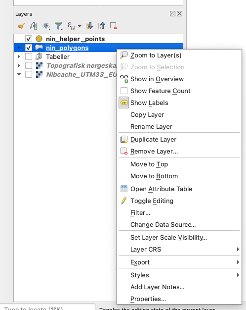

Skjermbilde 1 – Åpne egenskaper for laget

- Høyreklikk på laget (nin_polygons_, f.eks. nin_polygons_M005) i laglisten.
- Velg Properties… (Egenskaper) fra menyen.
- I dialogen som åpnes, velg fanen Fields i venstremenyen.

Dette viser alle eksisterende attributtfelt i laget.

## 2. Aktiver redigering av felt

[figure not shown]

Skjermbilde 2 – Aktiver redigering

- Klikk på blyant-ikonet øverst i feltlisten for å aktivere redigering av strukturen.
- Når redigering er aktivert, kan du legge til, slette eller endre felt.

## 3. Legg til nytt felt

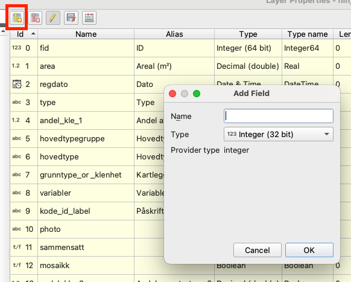

Skjermbilde 3 – Legg til felt

- Klikk på ikonet Legg til felt (gult ark med grønt plusstegn).
- Dialogen Add Field åpnes.

## 4. Opprett feltet NVE_ID

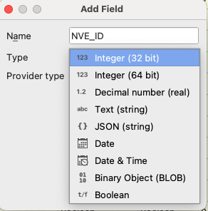

Skjermbilde 4 – Definer feltet NVE_ID

- Skriv NVE_ID i feltet Name.
- Velg datatype Integer (32 bit).
- Kontroller at Provider type settes automatisk til integer.
- Klikk OK for å opprette feltet.

Dette feltet brukes til å lagre numerisk ID fra NVE.

## 5. Opprett feltet firma

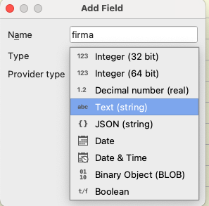

Skjermbilde 5 – Velg tekstfelt

- Klikk igjen på Legg til felt.
- Skriv firma i Name.
- Velg datatype Text (string).

## 6. Angi lengde for tekstfelt

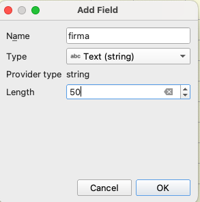

Skjermbilde 6 – Angi lengde

- Når datatype er satt til tekst, angi Length = 50.
- Klikk OK for å opprette feltet.

Dette bestemmer maksimal lengde på teksten som kan lagres i feltet.

## 7. Kontroller at feltene er lagt til

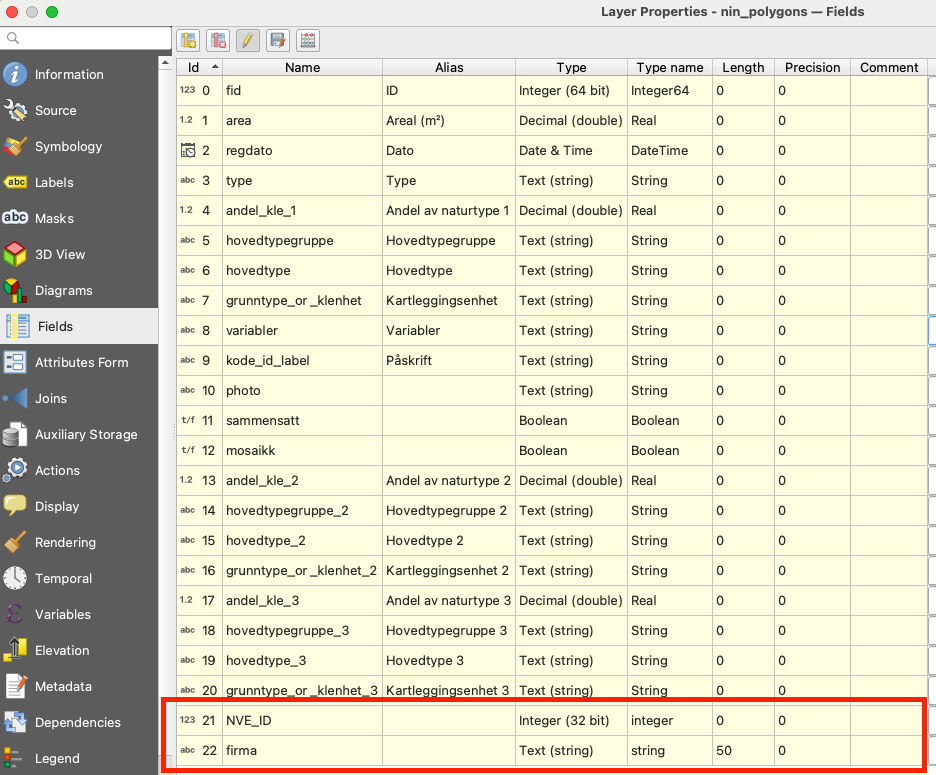

Skjermbilde 7 – Feltene er opprettet

- De nye feltene NVE_ID og firma vises nå nederst i feltlisten.
- Klikk Apply eller OK for å lagre endringene i lagets struktur.

## 8. Åpne fanen Attributes Form

[figure not shown]

Skjermbilde 8 – Attributes Form

- Gå til fanen Attributes Form i venstremenyen.
- Her konfigureres hvordan redigeringsskjemaet for laget skal se ut.

## 9. Flytt feltet NVE_ID inn i skjemaet

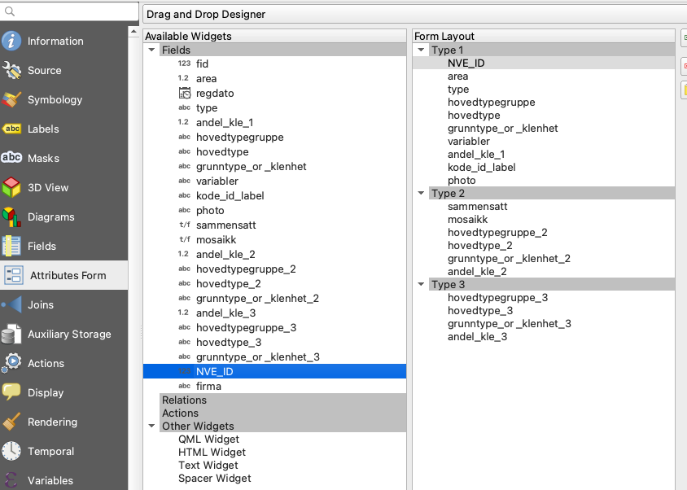

Skjermbilde 9 – Dra NVE_ID inn i skjema

- Finn feltet NVE_ID i listen Available Widgets.
- Dra feltet over til ønsket plassering i Form Layout (for eksempel øverst under Type 1).

## 10. Flytt feltet firma inn i skjemaet

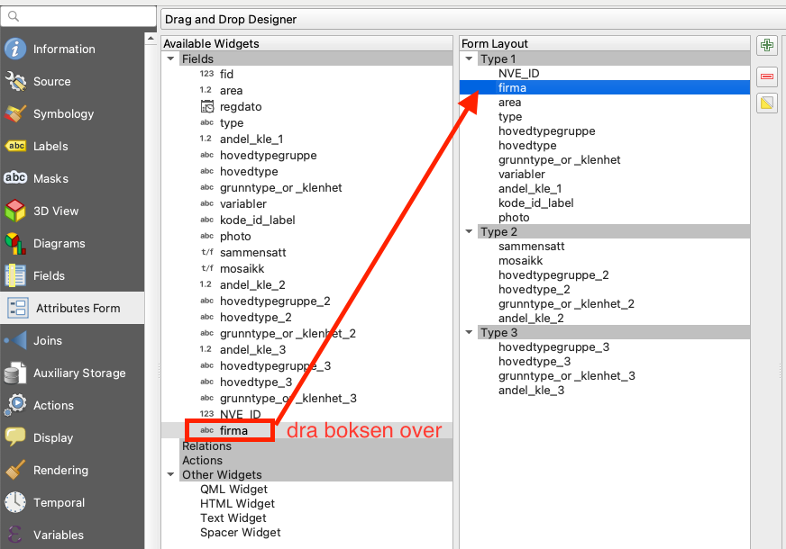

Skjermbilde 10 – Dra firma inn i skjema

- Finn feltet firma i Available Widgets.
- Dra feltet til ønsket plassering i skjemaet, rett under NVE_ID.

## 11. Lagre oppsettet

- Klikk Apply eller OK for å lagre skjemaoppsettet.
- Når du nå åpner attributtskjemaet for laget, vil feltene NVE_ID og firma vises i skjemaet.

## 12. Sett felttype til Value Map

[figure not shown]

Skjermbilde 11 – Velg Widget Type Value Map

- Marker feltet firma i Form Layout.
- I høyre panel, under Widget Type, velg Value Map.
- Dette gjør at feltet vises som en nedtrekksliste med forhåndsdefinerte verdier.

## 13. Legg inn verdier i Value Map

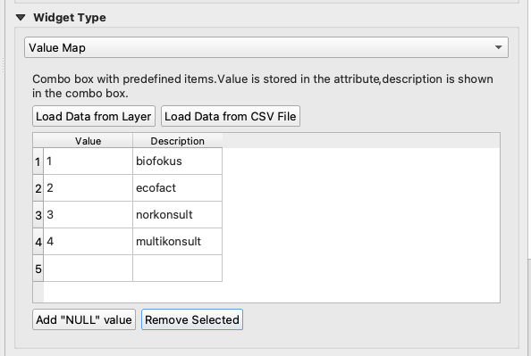

Skjermbilde 12 – Definer verdier i Value Map

- I tabellen under Value og Description, legg inn ønskede koder og visningsnavn:
  - 1 – biofokus
  - 2 – ecofact
  - 3 – norkonsult
  - 4 – multikonsult
- Alternativt kan du bruke Load Data from CSV File hvis listen finnes i en fil.

Verdien i kolonnen Value lagres i databasen, mens Description vises i skjemaet.

## 14. Kontroller skjemaet i redigeringsmodus

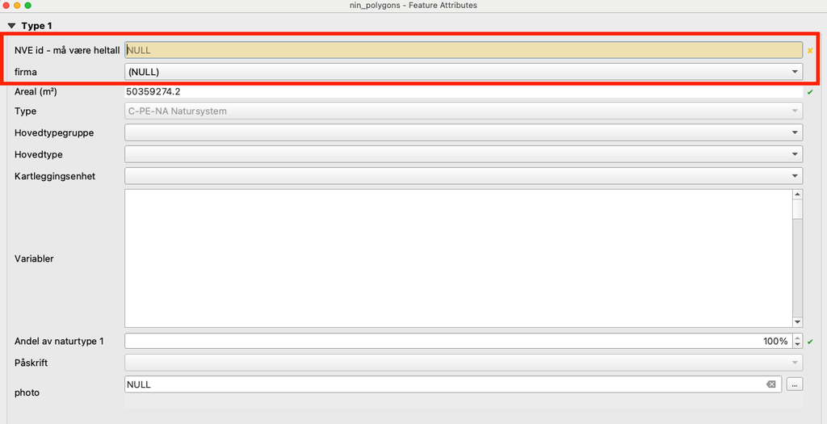

Skjermbilde 13 – Feltene vises i skjema

- Åpne attributtskjemaet for en flate i laget.
- Øverst i skjemaet vises nå feltene:
  - NVE id – må være heltall
  - firma (som nedtrekksliste)

Dette bekrefter at både nye felt og skjemaoppsett fungerer korrekt.

## 15. Velg verdi fra nedtrekkslisten

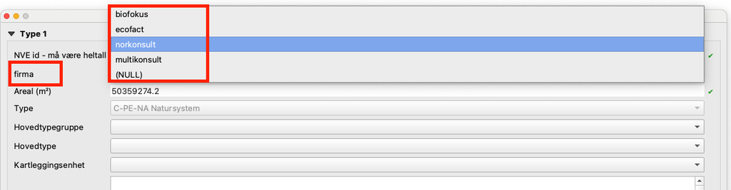

Skjermbilde 14 – Velg firma fra liste

- Klikk på nedtrekkslisten for feltet firma.
- Velg ønsket firma fra listen (for eksempel norkonsult).
- Verdien lagres automatisk når objektet lagres.

## Resultat

Du har nå:

- Opprettet nye felt i attributtabellen.
- Definert riktig datatype og lengde.
- Lagt feltene inn i redigeringsskjemaet slik at de kan fylles ut ved digitalisering eller redigering.
- Konfigurert feltet firma som en nedtrekksliste med forhåndsdefinerte verdier.

Denne strukturen fungerer direkte for eksport til HTML (for eksempel via MkDocs, Pandoc eller Sphinx).